# Introduction to R and R Objects

# R Data Types

There are six data types (modes) which describe how an object is being *stored* within R. There are four common modes, and two less common modes:

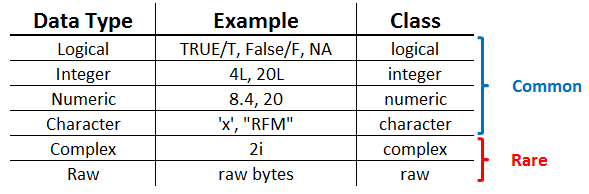

*Figure 1.4: List of R Data Types*

Things worth mentioning:

- If you need a number to be represented and stored as an integer, you must follow the number by the character ‘L’.=
- When using character strings in R, one can use either single or double quotes
- **R is case sensitive**

```r
# try executing the following expressions in your session, pay attention to the output!
"x" == "X"
"the" == "The"
T == TRUE
True == TRUE
```

# Special Values in R

- **NA**: a logical constant and special value in R representing that the value exsists but is unknown. There are several *flavors* of **NA**
  - You can test whether or not something is NA with **is.na()**. Many functions take the argument **na.rm =** which dropping NA values before the operation when set to TRUE
- **NULL**: a reserved word representing that the value does not exist
- **NaN**: Not-a-Number, what will be returned to the console if you enter 0/0
- **Inf/-Inf**: Infiniti, what will be returned to the console if you enter 1/0

```r
# NA does not equal NA (how could something you don't know equal another thing you also don't know)
NA == NA
```

```
## [1] NA
```

```r
# another example of how R handles NA values in operations
c(1:5, NA) + c(1, 2, NA, 4, 5, NA)
```

```
## [1]  2  4 NA  8 10 NA
```

```r
# a glipse at the difference btw NULL and NA in functions
sum(NA); sum(NULL)
```

```
## [1] NA
```

```
## [1] 0
```

# R Data Structures

The R language includes a full family of data structures. Always remember, **everything in R is an object**.

- Atomic Objects - **homogeneous** - can only contain *one* data type
  - **Vectors**: an ordered collection of elements that are all the same type
  - **Factors**: a vector object used to represent categorical data (categories referred to as *levels*). **Ordered**, factors assumes that there is a natural ranking to the categories
  - **Matrices**: 2-dimensional (n rows x m columns) generalizations of vectors. Matrices are a special case of arrays
  - **Arrays**: multi-dimensional generalizations of vectors (e.g. n rows x m columns x k layers)
- Multimodal Objects - **heterogeneous** - can contain *multiple* data types
  - **Data Frames**: tabular data structures in which the columns can be of different types, but all columns have the same length (think spreadsheet)
  - **Lists**: a general form of a vector in which various elements need not be of the same type. This is a recursive data structure, meaning that you can a list can contain elements that are, themselves, also lists
- **Functions**: package-defined and user-defined functions are themselves objects in R which can be stored in the project’s workspace

**Note** that there are two other R objects, **expressions** and **ts** (for time series), which will not be covered here.

# Summary of R Data Structures

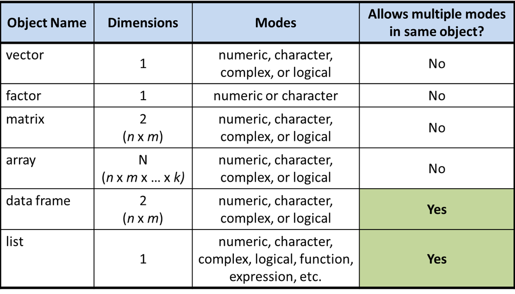

*Fig 1.5: Summary of Common Data Structures*